# Linear Regression Extensions - Tasks

Dr. Soliman

# Task 1: Non-linear relationships

1. Load the data [here](https://www.dropbox.com/scl/fi/68taafng8vjpzmub6q1xj/college_tuition_income.csv?rlkey=0c59a2kj0cwmcecjbg20jrkva&dl=0) and call the object `college`. This dataset contains information about tuition and estimated incomes of graduates for universities in the US.

```r
# change the path to yours
college <- read.csv("/Users/adamsoliman/Library/CloudStorage/Dropbox/Clemson/Econometrics Course/data for tasks/college_tuition_income.csv")
```

2. Create a scatter plot of estimated mid career pay (`mid_career_pay`) $(y-axis)$ as a function of out of state tuition (`out_of_state_tuition`) $(x-axis)$. Would you say the relationship is broadly linear or rather non-linear? Use `geom_smooth(method = "lm", se = F) + geom_smooth(method = "lm", se = F, formula = y ~ poly(x, 2, raw= T))` to fit both a linear and 2nd order regression line. This time which seems most appropriate?

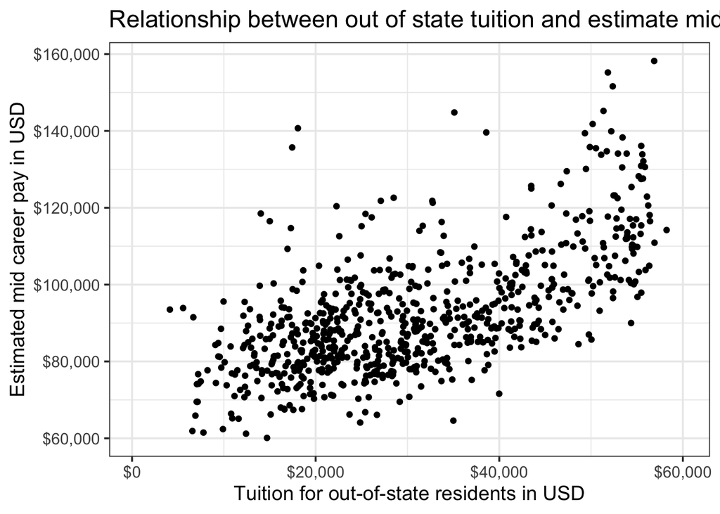

```r
base_graph <- ggplot(college, aes(x = out_of_state_tuition, y = mid_career_pay)) +
    geom_point() +
    labs(x = "Tuition for out-of-state residents in USD",
         y = "Estimated mid career pay in USD",
         title = "Relationship between out of state tuition and estimate mid career pay") +
    scale_x_continuous(labels = scales::dollar) +
    scale_y_continuous(labels = scales::dollar) +
    theme_bw(base_size = 14)
base_graph
```

**The relationship appears to be relatively linear though there is a some non-linearity at the upper end of the out of state tuition distribution, i.e. on the right-hand side of the graph. A 2nd order or 3rd order polynomial regression may be appropriate to capture it.**

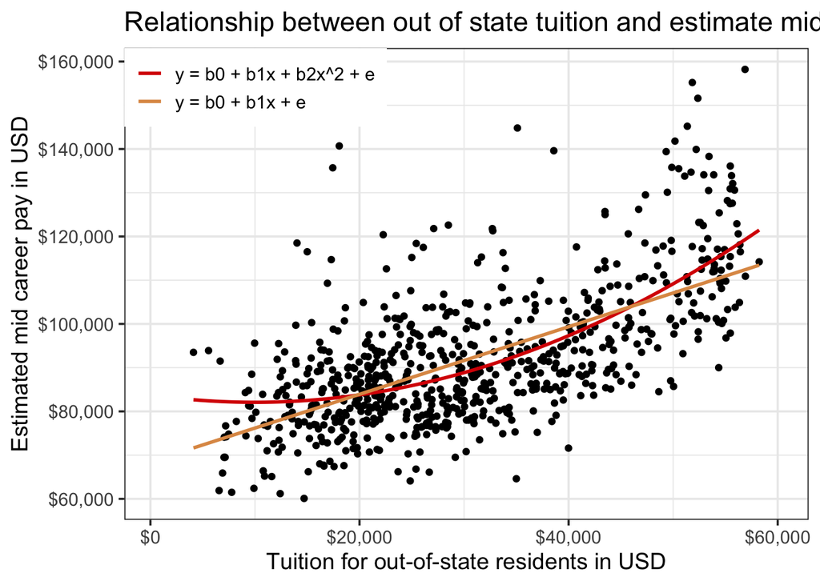

```r
base_graph +
    geom_smooth(method='lm', se = FALSE, formula = y~poly(x,2, raw = T), aes(colour="y = b0 + b1x + b2x^2 + e")) +
    geom_smooth(method='lm', se = FALSE, aes(colour="y = b0 + b1x + e")) +
    scale_colour_manual(name = NULL, values=c("#d90502", "#DE9854")) +
    theme(legend.position = c(0,1),
          legend.justification = c(0,1))
```

**Based on my first impressions, the 2nd order polynomial fit seems to be a bit better at capturing non-linearities to the left and right of the graph.**

3. Create a variable equal to out of state tuition divided by 1000 (note this means a one unit change in this variable is now a $1000 change) and filter the variable `type` to keep only the values of (“For Profit”, “Private”, “Public”). Call this object `college_clean`. Regress mid career pay on out of state tuition divided by 1000. Interpret the coefficients.

```r
college_clean <- college %>% filter(type %in% c("For Profit", "Private", "Public")) %>%
    mutate(out_state = out_of_state_tuition/1000)

lm(mid_career_pay ~ out_state, college_clean)
```

```
##
## Call:
## lm(formula = mid_career_pay ~ out_state, data = college_clean)
##
## Coefficients:
## (Intercept)    out_state
##     68462.4        772.3
```

**On average, a $1,000 increase in out of state tuition is associated with a $772 increase in estimated mid career pay. In this case, the model predicts that if a college had zero out-of-state tuition, the expected mid-career pay for its graduates would be $68,462.40, on average.**

4. Regress mid career pay on university type. Interpret each coefficient. What is the reference category?

```r
lm(mid_career_pay ~ type, college_clean)
```

```
##
## Call:
## lm(formula = mid_career_pay ~ type, data = college_clean)
##
## Coefficients:
## (Intercept)  typePrivate   typePublic
##       82400        11959         6145
```

**Intercept (82,400): This represents the expected mid-career pay for graduates of For-Profit colleges, as it is the reference category.**

**Private (11,959): Graduating from a Private college is associated with an increase of $11,959 in mid-career pay compared to a For-Profit college.**

**Public (6,145): Graduating from a Public college is associated with an increase of $6,145 in mid-career pay compared to a For-Profit college.**

5. Regress mid career pay on the logarithm of out of state tuition. You can either create a new variable using mutate, or incorporate the logarithm directly into the regression. Interpret the slope coefficient.

```r
lm(mid_career_pay ~ log(out_of_state_tuition), college_clean)
```

```
##
## Call:
## lm(formula = mid_career_pay ~ log(out_of_state_tuition), data = college_clean)
##
## Coefficients:
##               (Intercept)  log(out_of_state_tuition)
##                   -104152                      19188
```

**The slope coefficient, i.e. the one on log(out_of_state_tuition), means that a 1% increase in out-of-state tuition is associated with an increase of $191.88 (19188/100) in mid-career pay, on average. Note, the intercept isn’t very meaningful in this case, because for log-transformed independent variables, the intercept is often outside the range of observed data and doesn’t have a direct real-world interpretation.**

6. Regress the logarithm of mid career pay on the variable you created in #3 (`out_state`). Interpret the slope coefficient.

```r
lm(log(mid_career_pay) ~ out_state, college_clean)
```

```
##
## Call:
## lm(formula = log(mid_career_pay) ~ out_state, data = college_clean)
##
## Coefficients:
## (Intercept)    out_state
##   11.170414     0.008058
```

7. Regress the logarithm of mid career pay on the logarithm of out of state tuition. Interpret the slope coefficient.

```r
lm(log(mid_career_pay) ~ log(out_of_state_tuition), college)
```

```
##
## Call:
## lm(formula = log(mid_career_pay) ~ log(out_of_state_tuition),
##     data = college)
##
## Coefficients:
##               (Intercept)  log(out_of_state_tuition)
##                    9.3374                     0.2033
```

**A 1% increase in out-of-state tuition is associated with a 0.2033% increase in mid-career pay, on average. Alternatively, a 10% increase in out-of-state tuition is associated with a 2.033% increase in mid-career pay.**

## Task 2: Interacted models

1. Using the same dataset as before, `college_cleaned`, now filter out `type` (“Private”, “Public”), so that you only have private or public universities, and call the object `college_clean_really`. Also, create a variable equal to out of state tuition divided by 1000 (note this means a one unit change in this variable is now a $1000 change).

```r
college_clean_really <- college_clean %>% filter(type %in% c("Private", "Public")) %>%
  mutate(out_state = out_of_state_tuition/1000)
```

2. Run the following regression model `lm(mid_career_pay ~ out_state + type + type*out_state, data = college_clean_really).` Interpret the coefficients in the context of the model. Specifically, what does each coefficient represent, and how do the coefficients for out_state and type differ for public vs. private universities? Keep in mind what is the reference category.

```r
lm(mid_career_pay ~ out_state + type + type*out_state, college_clean_really)
```

```
##
## Call:
## lm(formula = mid_career_pay ~ out_state + type + type * out_state,
##     data = college_clean_really)
##
## Coefficients:
##          (Intercept)             out_state            typePublic
##             59515.88                956.27               8335.59
## out_state:typePublic
##                17.35
```

1. **Intercept: 59,515.88**  
   The baseline mid-career pay is $59,515.88 for private universities when out-of-state tuition (`out_state`) is $0.
2. **out_state: 956.27**  
   For private universities, each additional $1,000 increase in out-of-state tuition is associated with a $956.27 increase in mid-career pay.
3. **typePublic: 8,335.59**  
   Public universities have mid-career pay that is $8,335.59 higher than private universities, holding out-of-state tuition constant.
4. **out_state:typePublic: 17.35**  
   For public universities, the effect of out-of-state tuition on mid-career pay differs slightly from private universities. Specifically, for each $1,000 increase in out-of-state tuition, mid-career pay increases by an additional $17.35 compared to private universities.

Thereofre, for *Public universities*, the effect of a $1,000 increase in out-of-state tuition is $956.27 + $17.35 = *$973.62*.

## Task 3: Standardized regression

```r
grades <- read.csv("/Users/adamsoliman/Library/CloudStorage/Dropbox/Clemson/Econometrics Course/data for tasks/grade5_isl.csv")

reg_full <- lm(avgverb ~ classize + disadvantaged + school_enrollment + female + religious, grades)
reg_full
```

```
##
## Call:
## lm(formula = avgverb ~ classize + disadvantaged + school_enrollment +
##     female + religious, data = grades)
##
## Coefficients:
##       (Intercept)           classize      disadvantaged  school_enrollment
##         78.918736           0.003388          -0.389224           0.000807
##            female          religious
##          0.205981           2.886193
```

1. Create a new variable `avgmath_stand` equal to the standardized math score. You can use the `scale()` function (combined with `mutate`) or do it by hand with base `R`.

```r
# using scale()
grades <- grades %>%
    mutate(avgmath_stand = scale(avgmath))

# using base R
grades$avgmath_stand_2 <- (grades$avgmath - mean(grades$avgmath)) / sd(grades$avgmath)

identical(grades$avgmath_stand, grades$avgmath_stand_2)
```

```
## [1] FALSE
```

2. Run the full regression using the standardized math test score as the dependent variable. Interpret the coefficients and their magnitude.

```r
reg_full_stand <- lm(avgmath_stand ~ classize + disadvantaged + school_enrollment + female + religious, grades)
reg_full_stand$coefficients
```

```
##       (Intercept)          classize     disadvantaged school_enrollment
##       0.267825660       0.002518570      -0.036187960       0.001881792
##            female         religious
##      -0.017639979       0.118567071
```

**Interpretation for the class size coefficient: holding all the other regressors included in the regression constant, on average, a 1-student increase in class size is associated with a 0.003 standard deviation increase in average math scores. This is a very small association: 0.3% of a standard deviation.**

3. Create the standardized variables for each *continuous* regressor as `<regressor>_stand`. * Would it make sense to standardize the `religious` variable?

```r
grades <- grades %>%
    mutate(classize_stand = scale(classize),
           disadvantaged_stand = scale(disadvantaged),
           school_enrollment_stand = scale(school_enrollment),
           female_stand = scale(female))
```

**It would not make much sense to standardize the `religious` variable because it is a dummy variable, equal to 1 if the school is religious, and 0 otherwise.**

4. Regress `avgmath_stand` on the full set of standardized regressors and `religious`. Discuss the relative influence of the regressors.

```r
reg_full_stand_2 <- lm(avgmath_stand ~ classize_stand + disadvantaged_stand + school_enrollment_stand + female_stand + religious, grades)
reg_full_stand_2$coefficients
```

```
##             (Intercept)          classize_stand     disadvantaged_stand
##            -0.029186644             0.016531895            -0.488588700
## school_enrollment_stand            female_stand               religious
##             0.073054413            -0.008766237             0.118567071
```

**Interpretation for the class size coefficient: holding all the other regressors included in the regression constant, on average, a 1-standard deviation increase in class size (approx 6.5 students) is associated with a 0.02 standard deviation increase in average math scores. This is quite a small association: 2% of a standard deviation. Note that this coefficient can be otained by multiplying the class size coefficient from the previous question’s regression by the approx 6.5 (i.e. 1 standard deviation of the class size variable).**